# Assignment Week 3

### Name: Bram Otten

### ULCN: s2330326

We will compute or approximate the value of the expectation

$$I=E[\mathbb{1}(X > 1) X^2], \qquad X \sim \mathcal N(0, 1).$$

### Exercise 1. Importance sampling

- Obtain a Monte Carlo estimate of $I$ using importance sampling. (There are multiple solutions; make sure that your method is substantially more efficient than straightforward simulation from a normal distribution with mean zero.)

```r
f <- function(x) ifelse(x > 1, x ** 2, 0)
true <- integrate(function(x) dnorm(x) * f(x), -Inf, Inf)[1]$value

straightforwardI <- function(N) mean(f(rnorm(N)))

importanceI <- function(N) {
  # X ~ N(0, 1); Y ~ N(1, 1); g(X) = X ** 2 if X > 1, else 0
  Y <- rnorm(N, mean = 1)
  mean(f(Y) * dnorm(Y, mean = 0) / dnorm(Y, mean = 1))
}

N <- 10^4
straight_rep <- replicate(N / 10, straightforwardI(N))
importance_rep <- replicate(N / 10, importanceI(N))
true
```

```
## [1] 0.400626
```

```r
mean(straight_rep)
```

```
## [1] 0.4011761
```

```r
mean(importance_rep)
```

```
## [1] 0.4006613
```

- Calculate the MC approximation error.

```r
approximation_error_list <- c(
  straight_forward = sd(straight_rep),
  importance = sd(importance_rep)
)
approximation_error_list
```

```
## straight_forward       importance
##      0.011351122      0.004038614
```

And for completeness:

```r
rmse <- function(x) sqrt(mean((x - true) ** 2))
rmse_list <- c(
  straight_forward = rmse(straight_rep),
  importance = rmse(importance_rep)
)

rmse_list
```

```
## straight_forward       importance
##      0.011358773      0.004036748
```

### Exercise 2. Antithetic variables

- This time use antithetic variables for computing $I$.

```r
antitheticI <- function(N) {
  U <- runif(N / 2)
  Z <- c(X = qnorm(U), X_tilde = qnorm(1 - U))
  mean(f(Z))  # lol R
}

antithetic_rep <- replicate(N / 10, antitheticI(N))
mean(antithetic_rep)
```

```
## [1] 0.4006795
```

- Estimate the MC approximation error using simulation. Compare this to importance sampling.

```r
approximation_error_list <- c(
  approximation_error_list,
  antithetic = sd(antithetic_rep)
)
approximation_error_list
```

```
## straight_forward       importance       antithetic
##      0.011351122      0.004038614      0.010630122
```

The approximation error of this antithetic variables method seems higher than that of importance sampling, but lower than that of plain / straightforward Monte Carlo sampling.

```r
rmse_list <- c(rmse_list, antithetic = rmse(antithetic_rep))
rmse_list
```

```
## straight_forward       importance       antithetic
##      0.011358773      0.004036748      0.010624940
```

- Now combine antithetic variables with importance sampling to achieve maximal accuracy.

```r
antiImportant <- function(N) {
  # In antithetic's notation, X is now N(1, 1). Importance's Y is replaced by Z.
  U <- runif(N / 2)
  Z <- c(X = qnorm(U, mean = 1), X_tilde = qnorm(1 - U, mean = 1))
  mean(f(Z) * dnorm(Z, mean = 0) / dnorm(Z, mean = 1))
}

antiImportant_rep <- replicate(N / 10, antiImportant(N))
mean(antiImportant_rep)
```

```
## [1] 0.4005961
```

- Compute the MC approximation error and compare to the previous methods.

```r
approximation_error_list <- c(
  approximation_error_list,
  anti_important_mix = sd(antiImportant_rep)
)
approximation_error_list
```

```
##   straight_forward         importance         antithetic anti_important_mix
##       0.0113511217       0.0040386138       0.0106301218       0.0006410078
```

This is a much smaller approximation error than the previous methods obtained.

```r
rmse_list <- c(rmse_list, anti_important_mix = rmse(antiImportant_rep))
rmse_list
```

```
##   straight_forward         importance         antithetic anti_important_mix
##       0.0113587728       0.0040367481       0.0106249403       0.0006413813
```

### Exercise 3. Metropolis-Hastings

Let $f(x)=(2+\sin(1/x))\exp(-x^2)$.

- Use the Metropolis-Hastings algorithm to sample from the distribution with density proportional to $f$, and plot a histogram. Use a suitable proposal distribution.

Since $f = \psi$ is somewhat proportional to a normal density when its input is not too large, that seems like a handy proposal distribution. The $\sin(1/x)$ tends to 0 with large $x$ so a $\sigma=1$-normal’s tails are fatter, but the “acceptance rate” is quick enough to work with this.

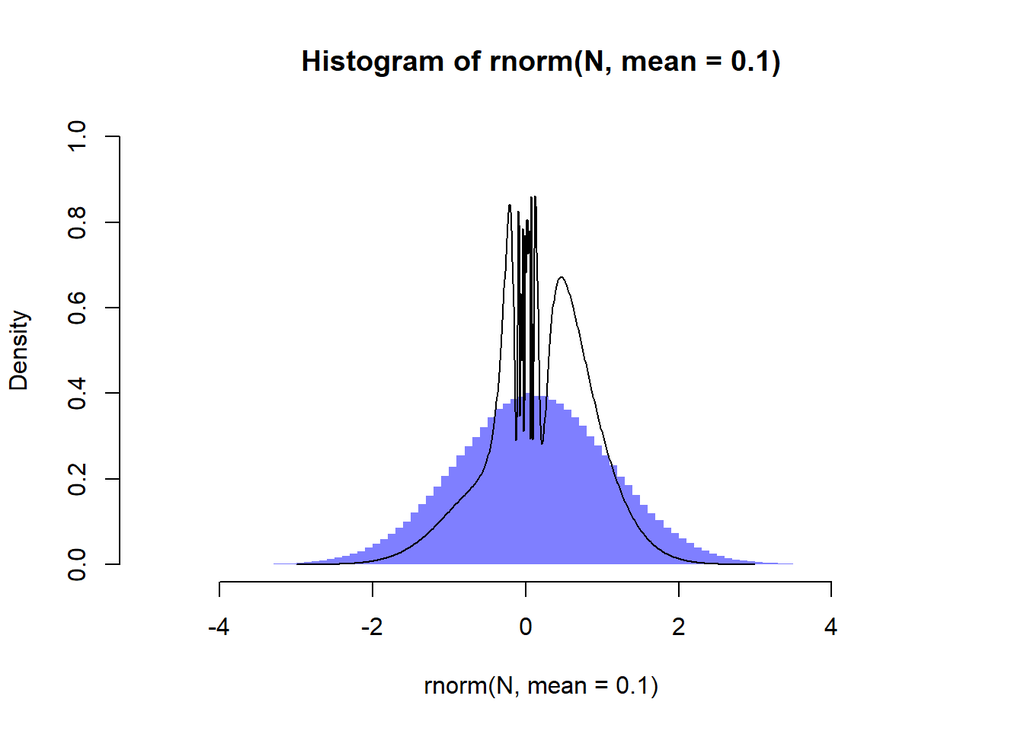

```r
# Let's call f "psi" to not overwrite and follow the slides.
psi <- function(x) (2 + sin(1 / x)) * exp(-x ** 2)
N <- 10^6

# Try a proposal
hist(rnorm(N, mean = 0.1), prob = TRUE, breaks = 100,
     border = NA, col=rgb(0, 0, 1, .5), ylim = c(0, 1))
X <- seq(-3, 3, by = 0.011)  # avoids evaluating f at 0
lines(X, psi(X) / 3.4)
```

```r
g <- function(Z, x) dnorm(Z, mean = x)
thresh <- function(Z, theta)
  psi(Z) * g(Z, theta) / (psi(theta) * g(theta, Z))

x_list <- c(0.1, rep(NA, N - 1))
for (t in 1:(N - 1)) {
  Z <- rnorm(1, x_list[t], 1)
  U <- runif(1)
  x_list[t + 1] <- ifelse(U < thresh(Z, x_list[t]), Z, x_list[t])
}

mcmc_samples <- x_list[-c(1:1000)]
```

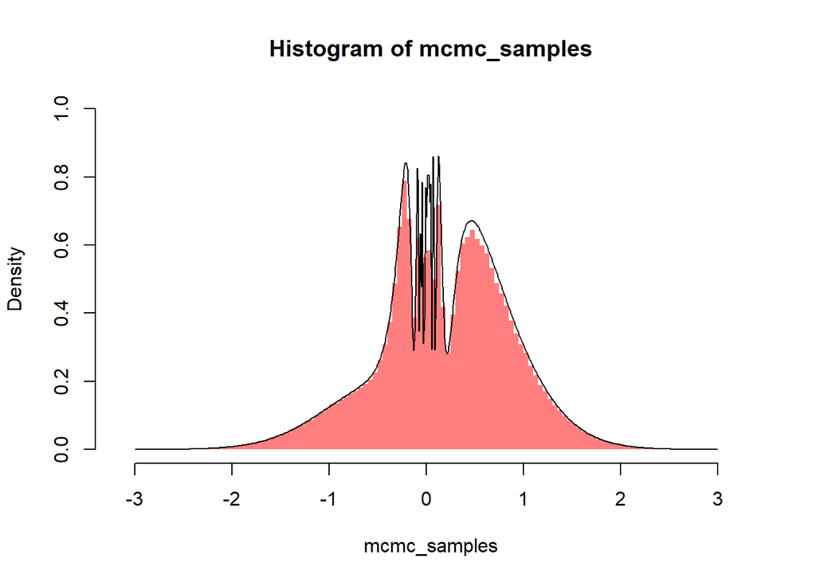

```r
hist(mcmc_samples, prob = TRUE, breaks = 100,
     col = rgb(1, 0, 0, .5), border = NA, ylim = c(0, 1))
lines(X, psi(X) / 3.4)
```